# Part II - Ford GoBike Visualizations Presentations

## by Maicy Maritim

## Investigation Overview

> I wanted to look at the most common user behaviours in relation to the usage of the Ford GoBike Share System. This covers Time, Gender and Age of each user type

## Dataset Overview

> Ford GoBike is a bike share used in the San Fransisco Bay Area, it contains multiple specially designed and durable bikes that can be used with no time limits. It is designed to enhance sustainable transportation in the Bay Area.

> Ford GoBike is designed for the hilly landscape of San Franciscoand are therefore built specially to be comfortable and easy to ride.

## Ford GoBike Usage by Day

> The bike sharing system is mainly used on the weekdays, with Thursday having the highest number of trips. There is a huge drop in the number of trips on the weekends. This suggests that the bike share system is primarily used for the purpose of commuting to and from work.

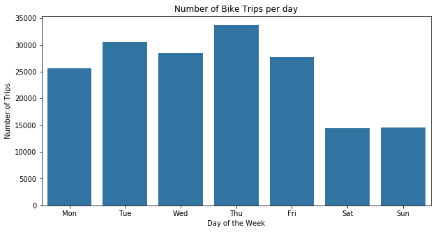

## Ford GoBike Usage By User Type

> Subscribers are the most frequent users of the Ford GoBike System on each day of the week.

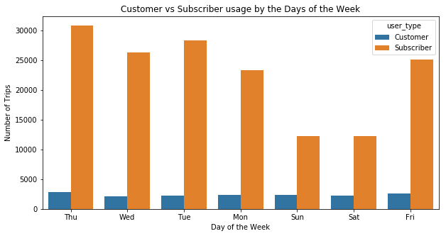

## Daily Bike Trips per Subscribers' Age Group

> - Subscribers within the age group 28-37 are the most frequent user of the bike share system.
> - Subscribers within the age group 68 - 99 are the least frequent users.
> - Thursday has the highest number of users in each age group
> - On the weekends, the number of bike rides drop significantly for most age groups except 68 - 99, which remains the same throughout the week

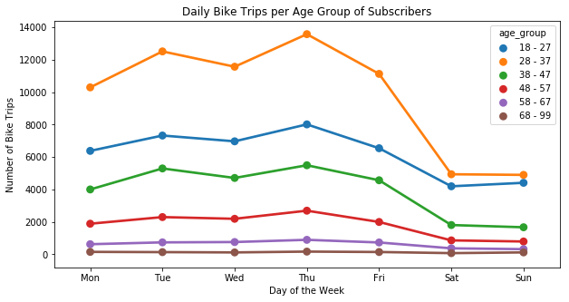

## Day and Time is the bike share system is mostly used by each User Type

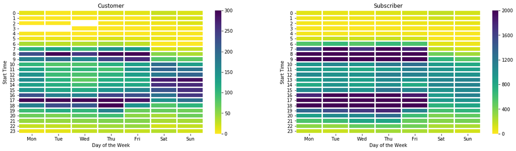

## Daily Usage per Gender and User Type

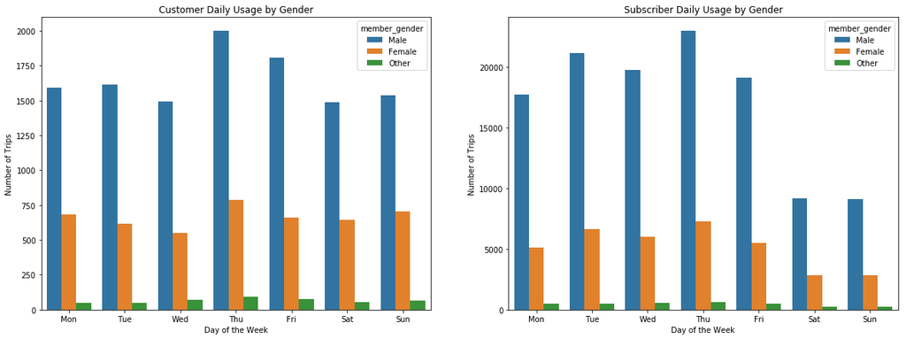